# Xetthecum Cultural Mapping Project

IMERSS biodiversity informatics working group

December 20th, 2023

## Introduction

Welcome to Xetthecum (in Hul’q’umi’num’ followed by English), an area on Galiano Island BC that is of ecological and cultural significance. Complex in its ecology, cultural history, and contemporary land-use, the boundary of Xetthecum is roughly delimited by the extent of the Greig Creek watershed, including the watercourse descending from Laughlin Lake to Retreat Cove, spanning residential and agricultural lands, protected and covenanted areas, and a public shore access.

[interactive chart not shown]

## Caves

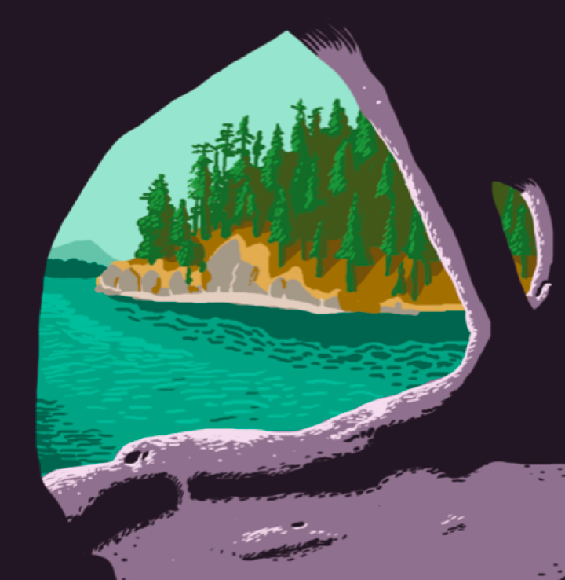

Spiritual cave Shhwuli’wun - praying for the spirit of the deer

Florence’s grandpa said the cave: if you take care of the deer when you kill a deer for food, its spirit will come and go; if you respect it when you kill it, it will always come back; respect the body and its parts; make use of its skin; the hooves and the skin were even used in the Big House.

Deer Island (Parker): There’s a mention that Parker Island was known as ‘Deer Island’ where deer ceremonies occurred.

Spiritual Significance: Florence mentioned that her grandfather used a specific cave called Shhwuli’wun as a sacred place for praying, particularly for the spirit of the deer. She recalled feeling emotional at this cave, mentioning that after her experience there, her mother passed away.

Ceremonial Importance: Retreat Cove, including its caves, served as locations for private ceremonies within the Penelakut community. Florence emphasized the significance of these caves for specific rituals, including training for ceremonies such as puberty rites.

Protective Measures: There were efforts made by someone named Ken to protect a hidden cave called Shqula’tsus, suggesting a community concern for safeguarding these culturally important sites.

Vandalism Concerns: Florence expressed concern about ongoing issues related to vandalism and damage occurring at the caves, highlighting the need to protect and respect these important cultural spaces.

Shqula’tsus —”a refuge, was protected by Ken (it is not on a map), a hidden cave”

## Historic and Cultural Significance

For generations, Galiano’s Indigenous communities have nurtured and honored the land. They’ve passed down traditions of sustainable resource use, respecting forests, freshwater sources, and oceans that provide life’s essentials.

Xetthecum is a place of private ceremonial importance to the Penelakut

The bay was a source of food. There were littlenecks in the spring towards the summer. These would be gathered during the night tides; the family would go there to gather traditional medicines at Laughlin Lake, such as a plant that has features similar to corn, like husk and silk. (Typha?, no it was another plant that was important); Florence and her family would gather food and medicines from all over the island depending on the season or what was needed. They are places on the island that were places of prayer and ceremony; Gathered at Xetthecum: Fireweed, xatisi, was used for stuffing sleep mats/beds (today can be found along Retreat Cove Road and at Laughlin Lake, AS); Mushrooms, kwmusuliqw or mumsilit; Octopus, xelex uwe, was speared usually at night; Protect the food sources. There are a lot of foods and medicines that are no longer there anymore

Food gathered in the bay in spring and summer: lots of ‘littlenecks’ there; low tides in winter at night; Wild blackberries were picked all the way from the Lighthouse down to Retreat Cove; they would wake at 5am with her granny and walk and collect the berries;

Florence’s family would go to Retreat Cove to harvest butterclams and littlenecks; Someone (Florence mentioned a name but I did not catch it?) would go to pick shellfish in the Spring; No clams on west beach near Hunterston Farms (Florence was disappointed in it); The delta at the mouth of Greig Creek: where they would harvest shellfish: inc. butterclams; Manilla, butter clams, littlenecks (Florence’s mom did not gather oysters); Shellfish laid overtop of kelp and then stepped on to get the water out; Ironwood singed in fire and then used to poke clams and stuck in the mud by the fire to cook them; Cedar bark turned to string/rope — also used to string up clams by the fire; After cooked, they would smoke the shellfish; Cockles–another important seafood harvested at Retreat Cove; Dog salmon released there when Ken was still alive (in Greig Creek)—confirm with Keith et al. (according to the records we have, it was Coho Salmon); Smelts would go by and move in circles, seagulls trying to get them; Florence’s family would sometimes travel to Retreat Cove in the racing canoe; They would pull in near Retreat Island; Florence’s grandfather would walk to Laughlin Lake for medicine; The fish had been restocked in Greig Creek just before the blasting happened near the mouth of Greig Creek

Historical Significance: Xetthecum held profound historical significance for the Penelakut community, serving as a crucial site for various traditional practices and resource gathering.

Traditional Practices: The location played a vital role in hosting traditional practices, notably puberty rites for both boys and girls, which were conducted within caves. Florence James discusses the importance of caves for puberty rites (Qw’uneem for boys and Xwutl’us for girls), showcasing their historical significance in the community’s cultural practices. These rites were essential to the cultural fabric and spiritual growth of the community, symbolising a connection to their heritage and spiritual beliefs.

Resource Gathering: Beyond its role in cultural ceremonies, Xetthecum was a primary resource-gathering area. Florence and her family gathered an array of resources from this place, including berries, fruit, and potentially shellfish. The bay provided not only essential foods but also medicinal resources, supporting both sustenance and ceremonial purposes for the community.

Cultural Significance: Xetthecum’s significance extended beyond its historical role; it was deeply entrenched in the cultural practices and spiritual beliefs of the Penelakut people.

Spiritual Connection: The site held significant spiritual value, particularly through the caves utilised for prayers, ceremonies, and the merging of spirits, notably those of humans and deer. The emotional experience Florence had in the cave, followed by her mother’s passing, highlights the profound spiritual importance attributed to Xetthecum.

Cultural Practices: The practices observed at Xetthecum were intricately tied to cultural rituals and beliefs. These traditions, including ceremonies associated with the deer and puberty rites, were foundational elements of the community’s cultural identity and historical heritage, emphasising the enduring importance of the site within the Penelakut culture.

“Xetthecum, acknowledged as a site of private ceremonial significance to the Penelakut people, held profound cultural and historical importance. This bay area served as more than just a coastal location; it was a pivotal source of sustenance and cultural practices for the community. The bay, particularly Xetthecum, played a vital role in the Penelakut’s livelihood. It provided a rich array of food resources, notably littleneck clams, harvested during the spring and summer night tides. Beyond shellfish, other essential marine life, such as butter clams, cockles, and fish like dog salmon, were gathered at Retreat Cove and Greig Creek. These resources sustained the community and formed a core part of their diet and traditional practices. Moreover, Xetthecum was not only a hub for food but also a source of traditional medicines. The area yielded plants resembling corn husk and silk that were utilised for their medicinal properties. This emphasised the bay’s significance beyond sustenance, encompassing the procurement of essential medicinal resources vital to the Penelakut’s well-being. The community engaged in specific and time-honoured gathering techniques, such as laying shellfish over kelp and using ironwood in cooking methods, demonstrating a deep understanding of the environment and the utilisation of natural resources in their practices. Regular and seasonal gatherings were part of the Penelakut’s cultural fabric, with activities like collecting wild blackberries and clam harvesting at Retreat Cove forming integral parts of their routines. Furthermore, historical records indicated conscious efforts to restock fish populations, emphasising their commitment to maintaining and enhancing local marine life. In essence, Xetthecum was not merely a geographical location but a sacred space embodying cultural heritage, serving as a crucial provider of sustenance, traditional medicines, and a testament to the Penelakut’s deep-rooted connection with the land and sea.”

Galiano Island has a rich cultural history, once cultivated by Indigenous peoples using controlled burns and selective logging. However, colonial practices disrupted traditional land use. Indigenous harvesting methods aimed to sustainably utilize forests. The island’s ecosystems hold spiritual significance for Indigenous communities, with specific areas like Retreat Cove and Grieg Creek serving as important fishing and ceremonial sites.

## Retreat Cove

[interactive chart not shown]

Rosemary Georgeson: “I used to spend time up in Xetthecum with my grandparents visiting with friends and picking berries and fruit. Sometimes we would anchor in there if we had to when we were on the boats.”

Cultural Practices and Ceremonies: Retreat Cove and surrounding areas were crucial sites for puberty rites, prayers for the spirit of the deer, and other spiritual practices. These locations held significant cultural and spiritual value for the community. Resource Gathering: The area was rich in resources, including various species of shellfish, clams, berries, and mushrooms. Gathering food and medicines from Retreat Cove was an essential practice for sustenance and ceremonial purposes. Florence mentions gathering licorice fern root from maple trees near Retreat Cove, illustrating the specific location’s significance for traditional harvesting practices. Spiritual Significance: Mention of caves being used for prayers, ceremonies, and the merging of human and deer spirits emphasises the spiritual connection of these places. Challenges in Access: Challenges are mentioned regarding accessing traditional areas due to private ownership, tourism, and restrictions, impacting the community’s ability to practice traditions and gather resources.

Lorne Silvey mentions Xetthecum as being important for social and cultural gatherings, as well as for traditional activities such as fishing and clam digging.

Retreat Cove, a marine location, has been significant for fishing and was a habitat for rockfish, but it is now a marine protected area to conserve these species due to overfishing and habitat destruction.

## Grieg Creek

Grieg Creek, once home to abundant salmon, now sees efforts to restore these vital fish populations. Indigenous and non-Indigenous communities are working together to enhance habitats, fostering the return of these cherished fish.

Efforts are being made to restore Coho and Chum salmon populations in Grieg Creek, primarily through stream bank restoration and salmon fry release by local schools. This activity is an educational and cultural experience for both Indigenous and non-Indigenous children.

## Laughlin Lake

Cat tails: you can eat the base of the plant, looks like celery, you can eat it; when you cut the top to use the bullrush, you can use the root as a vegetables

fireweed (used to stuff cushions); Cat-tail, bull rush, used for mats; An 800 year old cedar could be used to make four canoes

Florence highlights the use of fireweed (xatisi) found at Laughlin Lake, emphasising the significance of this area for sourcing specific plant resources.

Laughlin Lake symbolizes the island’s freshwater ecosystems. Its waters sustain diverse life, supporting culturally significant species and serving as a haven for both wildlife and people.

Laughlin Lake represents a complex wetland ecosystem supporting a diversity of plant life, including culturally significant reeds like cattails. The riparian areas around the lake are crucial for wildlife, offering habitat for species like black-tailed deer and great blue herons.

## Delta

The Delta area shows the impact of colonial practices on freshwater ecosystems, leading to alterations in streams, wetlands, and riparian areas due to resource extraction, logging, and agriculture. These activities have disrupted the natural flow and stability of water bodies.

## Cultural Values: Marine

Xetthecum (Retreat Cove/Island) is one of the few marine locations on the shoreline of Galiano itself that has been an important place for fishing and harvesting shellfish. Its desirability as a habitat for rockfish in particular has since become so notable that it has been designated a marine protected area—in which fishing is banned—in order to conserve these long-lived species that are slow to reproduce. As the tide is not too fast, Xetthecum was once also a good area for other creatures, such as clams, pun’eq’ (geoduck) and dog fish. It is important that community members are able to harvest and consume these foods without getting sick, therefore environmental health of the ocean is vital.

Lorne Silvey’s activities like fishing, clam digging, and berry picking showcase the cultural significance of marine and freshwater resources, reflecting the importance of these environments in his culture.

Florence talks about the significance of various marine resources like clams, shellfish, and smelts, indicating the cultural importance of these resources and the rituals associated with harvesting them.

The ocean is more than a source of food; it’s a cultural hub. Indigenous and non-Indigenous communities share a deep connection to marine life, using traditional knowledge to respect and sustainably harvest from these waters.

The marine environment is essential for both Indigenous and non-Indigenous communities for sustenance, livelihoods, and cultural practices. Fishing, shellfish harvesting, and marine tourism are vital for the island’s economy and traditional ways of life.

## Cultural Values: Freshwater

Wetlands on Galiano include lakes, shallow water, swamps, marshes, wet meadows, fens, and bog communities, many of which are represented in the watershed that flows into Xetthecum. Swamps and riparian areas include flood-tolerant trees such as xpey’ (western red cedar) which “like to have their feet wet”, kwulala’ulhp (red alder), whose inner bark offers a source of emergency food in the spring, and swele’ulhp (willow), which is useful for making fish traps. Other helpful plants that grow here include stth’e’qun (cattail) which provides a useful source of materials for both binding and insulation, sxum’xum’ (horsetail), which makes a yellow brown dye and ts’a’kw’a’ (skunk cabbage) which can be used to wrap food to keep it fresh. These areas are prized for berry-picking and gathering other edible and medicinal plants such as lila’ (salmonberry), t’uqwum’ (thimbleberry), t’eqe’ (salal), suniiulhp (oregon grape), sqw’uqwtsus (red huckleberry) and me’uwhulhp (Labrador tea).

A diversity of plant life, bacteria and insects thrive in wetland ecosystems, forming complex food webs that support many culturally important species, such as stseelhtun (salmon). Thuqi’ (sockeye salmon) and haan (pink salmon) are two types of salmon favoured by Indigenous community members on Galiano. In addition, the enhanced growth and forest structure found in riparian areas provides necessary cover for wildlife, which is also important for culturally significant activities such as hunting and birdwatching. Ha’put (black tailed deer) and smuqw’a’ (great blue heron) depend on freshwater areas for food and water.

Lorne Silvey’s activities like fishing, clam digging, and berry picking showcase the cultural significance of marine and freshwater resources, reflecting the importance of these environments in his culture.

Freshwater habitats like rivers and wetlands hold deep cultural significance. They support salmon runs, essential for Indigenous practices, while facing challenges from historical alterations.

The marshes, wetlands, and riparian areas on Galiano form a rich tapestry of life. These areas, though altered by settlers in the past, remain important for Indigenous practices, supporting plants used in ceremonies and daily life.

Freshwater areas, including wetlands, lakes, and streams, have cultural importance for fishing, habitat sustenance, and traditional education, with programs focusing on salmon egg hatching and release for local students.

## Cultural Values: Forest

Forests provide shelter, clean water, and food, the foundations for a complex web of life in which we are intricately connected. Humans have been stewarding forests on Galiano since time out of mind, in order to ensure key species that we depend on can flourish and help us thrive.

Moister forests are characterized by towering ts’sey (Douglas-fir) and robust xpey’ (western red cedar), which is known as the ‘tree of life’, as it can provide essential material for everything from ocean-worthy canoes, to rot-resistant buildings, beautiful carvings, and woven rain hats. The most valuable xpey’ for these purposes are old growth trees, which are allowed to grow slowly for hundreds of years in order to provide fine and clear-grained bark for weaving and wood for carving. Traditional Indigenous harvesting methods of only taking a strip of bark or plank of wood from one side can allow such trees to survive, heal and continue growing. The understory in this type of forest is dominated by plants that can grow in symbiosis with the fungicide xpey’ releases into the soil to discourage competition from other plants. This type of forest is often thick with t’eqe’ (salal) and suniiulhp (tall oregon grape), both of which provide nutritious berries, as well as sthxélem (sword fern), which is a spiritually significant plant that also provides fiddleheads as a special winter treat.

These older forests are models of complexity, exhibiting a vast diversity of composition (the parts), structure (the arrangement of the parts), and function (how the parts interact with one another). Big ts’alhulhp (bigleaf maple) that are covered in moss offer habitat for other culturally significant species, such as tl’usiip (licorice fern), which Florence James shared can be used as a sweetener: if one gently lifts the moss with your pinky to reveal the root, the licorice fern root can be rinsed, chopped up, mixed with berries and placed on a board in the sun to dry. If it is flipped the next day to dry the other side, this can be kept to have on hand.

Florence mentions gathering licorice fern root from maple trees near Retreat Cove, illustrating the specific location’s significance for traditional harvesting practices.

Florence stresses the importance of sustainable practices like taking care of oak trees and maintaining the forest floor to prevent forest fires, underlining the environmental significance of these practices for ecosystem preservation.

Florence discusses traditional forestry practices involving the care of trees, preventing forest fires, and using resources like cedar bark, ironwood, and cedar for various purposes, showcasing the cultural importance of forests and their resources.

The forests of Galiano are repositories of cultural heritage. Indigenous communities have nurtured these lands, using trees and plants not just for practical purposes but also in ceremonies and spiritual practices.

Forests are culturally significant, providing not only resources for construction, carving, and weaving but also holding spiritual value.

## Cultural Values: Woodland

p’hwulhp (Garry Oak) as evidence that the land is being taken care of, and (Florence) calls this type of ecosystem shthuliim: “a beautiful meadow with cushions for your feet made of moss, tender growth, grass…” She adds that p’hwulhp was made crooked by the creator so that its branches are useless to people and it will be left alone. James told us that pheasant, quail, and grouse were a lot more abundant in these woodland meadow environments, and that they used to be a regular part of Indigenous people’s diets in this area. Like speenhw, the bulbs of stl’ults’uluqw’us (chocolate lily / tiger lily) are very beautiful and edible when cooked. Florence James used to collect fawn lilies and ti’tuqw-el’tun’ (lady slippers) for her mother, as her mother would eat the bulbs. “That was just our joy”… but there is not enough to collect anymore.” Other culturally significant species include t’uliqw’ulhp (yarrow) and q’uxmin (barestem desert parsley / wild celery), which are prized for their medicinal qualities.

Fields of speenhw (Blue Camas) have been cultivated for thousands of years by First Nations Camas Keepers throughout this region, creating unique ecosystems that are not found anywhere else in the world. Florence calls this plant Quma’s, and shared there is a face in the shape of the flower.

Dry ridges or steep southwest facing slopes with nutrient poor, shallow soils tend to be dominated by a mix of gnarled ts’sey (Douglas-fir) and qaanlhp (arbutus), and shrubby species such as lulutth’sulhp (dull oregon grape) or Xwiinlhp (baldhip rose), all of which provide medicine. These drier ecological communities are mapped as woodlands in this map. Jeannine’s interview’s discussion about wood harvesting, the types used, and sustainable practices reflects the cultural significance of the forest and woodland resources for Galiano Island’s inhabitants.

Florence mentions the gathering of specific plants like licorice fern root and their specific usage, possibly highlighting the significance of woodlands in providing these resources. Woodlands are integral to Galiano’s culture. These spaces hold specific plants and trees used for medicinal, spiritual, and practical purposes, reflecting the deep knowledge passed through generations.

The woodlands hold diverse plant life used for food, medicine, and materials by Indigenous communities.

## Biodiversity

The mention of various fish caught around Galiano Island like cod, herring, salmon, crab, and octopus highlights the island’s rich biodiversity. [Jeannine’s interview]

Florence refers to various species like deer, seals, and different fish, emphasising the importance of these species for food and cultural practices.

Galiano’s diverse ecosystems host a multitude of species. From ancient forests to vibrant underwater worlds, this biodiversity forms intricate webs of life, sustaining the island’s natural balance.

Galiano Island’s ecosystems exhibit high biodiversity, supporting a variety of species, including salmon, black-tailed deer, eagles, and numerous plant species, both culturally significant and ecologically important.

## Community Connection

Lorne Silvey’s mentions of places like the Reservation, Xetthecum, and Kiyo’s highlight these areas’ significance for social and cultural gatherings, emphasising their role in fostering community connections and traditions.

Florence discusses her family connections, hereditary ownership of specific lands, and relationships with other families and communities, showcasing the community’s interconnectedness.

The people of Galiano are intertwined with nature. Traditional practices, gatherings, and shared knowledge underscore the deep relationship between the community and the island’s ecosystems.

## Preservation Efforts and Future Vision

The concerns raised about challenges in fishing due to coho fishery closure and the impact of logging industry hint at the need for preservation efforts and the articulation of a future vision to sustain these resources. [Jeannine’s interview]

Florence emphasises the need to protect and conserve resources, suggesting a future vision that involves sustainable practices and preserving traditional knowledge for future generations.

Xetthecum is a vital marine sanctuary on Galiano Island. It’s a protected area crucial for preserving rockfish and shellfish populations, ensuring their continued existence for future generations.

Galiano’s ecosystems, including Xetthecum, from lush forests to thriving marine environments, are interconnected and crucial for sustaining life. They provide resources, shelter, and inspiration, forming the foundation of the island’s health and eco-cuultural identity.

Efforts to preserve Galiano’s natural heritage are ongoing. Restoration initiatives, coupled with the desire to uphold Indigenous wisdom and practices, aim to safeguard the island’s resources for future generations.

Efforts are ongoing to protect and restore the island’s ecosystems. However, colonial practices, invasive species, and industrial impacts threaten these efforts. Both Indigenous and non-Indigenous communities are actively involved in preserving and reconnecting with the land through various educational initiatives and conservation projects, aiming for a sustainable future vision for Galiano Island.